# Is COVID-19 Affecting Census Response Rates?

### By Benjamin Livingston, [*NewsCounts*](http://newscounts.org)

### March 27, 2020

## Introduction

COVID-19 has shut down much of America, including [the United States Census Bureau's field operations](https://www.nytimes.com/2020/03/18/us/virus-census-homeless.html).

This raises the question - it there a correlation between COVID-19 prevalence and census response rates?

We aim to answer that question with a brief exploration here.

To do this, we examined [county-level COVID-19](https://www.nytimes.com/article/coronavirus-county-data-us.html) data that was readily available, and paired it with the official census return rate numbers to gauge a possible connection. We then generated infection rates for each county by normalizing on each county's population estimate from the 2018 American Community Survey.

There are a few important caveats here:

- COVID-19 data is believed to be highly inaccurate, and may be more accurate in areas with certain demographics (skewing this data), perhaps due to more widespread testing and case tracing
- These are only *confirmed* cases - there could be many cases that have not been properly identified yet for these same reasons
- On a similar note, many cases in some states have not been assigned to a county, and have a county label as "unknown"; thus, while examining data at the county level gives us the power of granularity, there is some information loss
- Many counties have zero reported cases, so the data could be biased by the characteristics of which counties report cases and which counties do not report cases

Our findings are presented below.

# Code

```python
# import packages
import pandas as pd
import requests
import json
import numpy as np
from datetime import datetime

now = datetime.now()
print('Analysis run at ',now)

# define api key
key = '2988f01f5e86175bda8beae2b5035e1ccef2d052'

# read COVID-19 data
covid = pd.read_csv('https://raw.githubusercontent.com/nytimes/covid-19-data/master/us-counties.csv')
covid = covid.iloc[:,-3:-1]
covid = covid.groupby('fips').sum()

# pull population data to incorporate
populations = pd.DataFrame(columns=['B01003_001E','B02001_002E','B02001_003E','B02017_001E',\
                                    'B02001_005E','B02001_006E','B02001_007E','B02001_008E',\
                                    'B03002_012E','C18108_002E','B05001_006E','B99051_005E',\
                                    'B17001_002E','B08519_009E','county','state'])
for i in range(79):
    if i < 10:
        url = 'https://api.census.gov/data/2018/acs/acs5?get=B01003_001E,B02001_002E,B02001_003E,B02017_001E,'\
        +'B02001_005E,B02001_006E,B02001_007E,B02001_008E,B03002_012E,C18108_002E,B05001_006E,B99051_005E,'\
        +f'B17001_002E,B08519_009E&key={key}&for=county:*&in=state:0' + str(i)
    else:
        url = 'https://api.census.gov/data/2018/acs/acs5?get=B01003_001E,B02001_002E,B02001_003E,B02017_001E,'\
        +'B02001_005E,B02001_006E,B02001_007E,B02001_008E,B03002_012E,C18108_002E,B05001_006E,B99051_005E,'\
        +f'B17001_002E,B08519_009E&key={key}&for=county:*&in=state:' + str(i)
    try:
        JSONContent = requests.get(url).json()
        temp = pd.DataFrame(JSONContent)
        temp.columns = temp.iloc[0]
        temp = temp.iloc[1:,:]
        populations = pd.concat([populations,temp],sort=True)
    except json.JSONDecodeError:
        pass

# rename columns
populations.columns = ['population','white','black','AIAN','asian','pacific_islander',\
                'other_race','multiracial','hispanic',\
               'under18','noncitizen',\
               'foreign_born','below_poverty_level','make_over_75k','county','state']

# parse population to float
populations.population = populations.population.astype('float')


# parse demographic data to float and normalize by population
for column in populations.columns:
    if column not in ['population','county','state']:
        populations[column] = populations[column].astype('float')
        populations[column] = populations[column] / populations['population']

# add fips codes for populations
populations['fips'] = populations['state'].astype('str') + populations['county'].astype('str')
populations['fips'] = populations['fips'].astype('int64')

# get column names
url = f"https://api.census.gov/data/2020/dec/responserate?get=GEO_ID,CRRALL,CRRINT,DAVG,DINTAVG,DRRALL,DRRINT&key={key}&for=state:*"
JSONContent = requests.get(url).json()
labels = pd.DataFrame(JSONContent).iloc[0,:-1]
county_responses = pd.DataFrame(columns=labels)

# pull county response data
for i in range(79):
    if i < 10:
        url = f"https://api.census.gov/data/2020/dec/responserate?get=GEO_ID,CRRALL,CRRINT,DAVG,DINTAVG,DRRALL,DRRINT&key={key}&for=county:*&in=state:0"\
        + str(i)
    else:
        url = f"https://api.census.gov/data/2020/dec/responserate?get=GEO_ID,CRRALL,CRRINT,DAVG,DINTAVG,DRRALL,DRRINT&key={key}&for=county:*&in=state:"\
        + str(i)
    try:
        JSONContent = requests.get(url).json()
        temp = pd.DataFrame(JSONContent)
        temp.columns = temp.iloc[0]
        temp = temp.iloc[1:,:]
        county_responses = pd.concat([county_responses,temp],sort=True)
    except json.JSONDecodeError:
        pass

# fill unreported statistics with nans
stats = county_responses.columns[:-3]
for column in stats:
    county_responses[column] = county_responses[column].astype('float')
    county_responses[column] = county_responses[column].replace(0,np.nan)

# merge demographic data and response data
populations = pd.merge(populations,county_responses,'inner',['state','county'])

# merge population data into county reponses
populations = populations.drop(columns=['county','state','GEO_ID'])


# merge data for all counties
full_data = pd.merge(covid,populations,'right','fips')
full_data.cases = full_data.cases.fillna(0)
full_data['cases'] = full_data['cases'] / full_data['population']
full_data = full_data.drop(columns=['fips'])

# rename variables
variables = ['COVID-19 Cases','population','white','black','AIAN','asian','pacific_islander',\
             'other_race','multiracial','hispanic','under18','noncitizen','foreign_born','below_poverty_level',\
             'make_over_75k',\
             'Cumulative Self-Response Rate - Overall',\
             'Cumulative Self-Response Rate - Internet',\
             'Average Daily Overall Self-Response Rate',\
             'Average Daily Internet Self-Response Rate',\
             'Maximum Daily Intenet Self-Response Rate',\
             'Median Daily Internet Self-Response Rate']

full_data.columns = variables
```

```
Analysis run at  2020-03-27 11:21:35.801218
```

# Results

## Technical Details

I will use a log scale for COVID-19 cases, in order to properly reflect that they are growing exponentially. In short, this will allow us to better gauge the relationship between prevalence of reported COVID-19 cases and other factors we are examining.

I'll also normalize infection totals by county population, so we get infection rates, rather than raw numbers of infections.

For reference while reading these results: *correlations* range on a constant scale from -1 (perfectly negatively correlated), to 0 (absolutely no correlation), to 1 (perfectly positively correlated) - which is to say if a value is very close to zero, two factors are not correlated. Generally, a correlation would need to be at or above .3 or at or below -.3 for us to consider it at least moderately significant.

It is vital to note that correlation does *not* imply causation - we are simply noting that areas with certain demographics tend to have higher (or lower) reported infection rates (and again, these are *reported*, *county-assigned* infections), not definitely stating that certain groups are infected by the virus more frequently than others.

## Effects On Various Socioeconomic Groups

The first thing to examine is this: is COVID-19 affecting various hard-to-count groups differently?

When we do this, we see a few interesting trends.

```python
full_data_log = full_data.copy()
full_data_log = full_data_log.astype('float32')
full_data_log['COVID-19 Cases'] = full_data_log['COVID-19 Cases'].replace(0,1)
full_data_log['COVID-19 Cases'] = np.log(full_data_log['COVID-19 Cases'])

results_cors = pd.DataFrame(full_data_log.corr().round(2))
results_cors.to_html('correlations_full_data.html')
full_data_log.dropna().to_csv('full_data.csv')
results = pd.DataFrame(results_cors.iloc[1:15,0])
results.columns = ['Correlation with COVID-19 infection rates']
results
```

|  | Correlation with COVID-19 infection rates |
| --- | --- |
| population | -0.22 |
| white | 0.13 |
| black | -0.15 |
| AIAN | -0.21 |
| asian | -0.02 |
| pacific_islander | 0.04 |
| other_race | -0.09 |
| multiracial | 0.07 |
| hispanic | 0.09 |
| under18 | -0.12 |
| noncitizen | -0.10 |
| foreign_born | 0.14 |
| below_poverty_level | -0.19 |
| make_over_75k | -0.06 |

- More populous areas are less prone to infection
- More populous areas have more difficulty robustly testing their large population
- Cases are fairly evenly spread throughout the country regardless of population density
- Any of a number of other factors

...but we can't say for sure.

We don't see too much correlation between prevalence of certain racial groups and rate of reported COVID-19 infections, except for American Indians & Alaska Natives (AIAN) - perhaps their natural social distancing and distance from population centers could be an asset here.

While the correlation is quite weak, it is interesting to note that areas with more minors tend to have have very slightly lower infection rates, which is unsurprising given that COVID-19 is well-known to have a greater effect on older adults, which may lead to adult cases being reported more frequently.

It is also worth noting that we observe the correlation between prevalence of foreign-born populations and prevalence of reported COVID-19 infections is positive, but very slight.

Finally, we note the negative correlation between poverty and prevalence of confirmed COVID-19 cases - this number isn't particularly significant, but this would stand in line with the belief that underprivleged citizens are not receiving proper testing. The same could be said of white populations versus African-American populations. So, perhaps it would not make sense to assume that at-risk populations are being infected less frequently.

**However**, it is vital to note that these correlations are *all* weak, so drawing conclusions from any of them may be shortsighted.

So it seems that, generally, most of these racial and economic demographic factors correlate little with reported COVID-19 infection rates.

## Effect On Census Response Rates

We will now examine the correlation between census response rates and prevalence of confirmed COVID-19 cases

For reference while reading these results:

- “Internet” rates are calculated as the percent of all housing units who responded online.
- “Overall” response rates are calculated as the percent of online, mail, and phone self-responses collectively.

```python
new_results = pd.DataFrame(results_cors.iloc[-6:,0])
new_results.columns = ['Correlation with COVID-19 infection rates']
new_results
```

|  | Correlation with COVID-19 infection rates |
| --- | --- |
| Cumulative Self-Response Rate - Overall | -0.26 |
| Cumulative Self-Response Rate - Internet | -0.41 |
| Average Daily Overall Self-Response Rate | -0.35 |
| Average Daily Internet Self-Response Rate | -0.44 |
| Maximum Daily Intenet Self-Response Rate | -0.36 |
| Median Daily Internet Self-Response Rate | -0.45 |

Examining the data, we see a fairly substantial negative correlation between reported COVID-19 cases and census self-response rates.

This means that where there are more reported COVID-19 cases, people tend to fill out their census forms less, to a pretty noticeable degree.

## Visualization

We can get a sense of the negative trend by looking at it in a simple scatterplot.

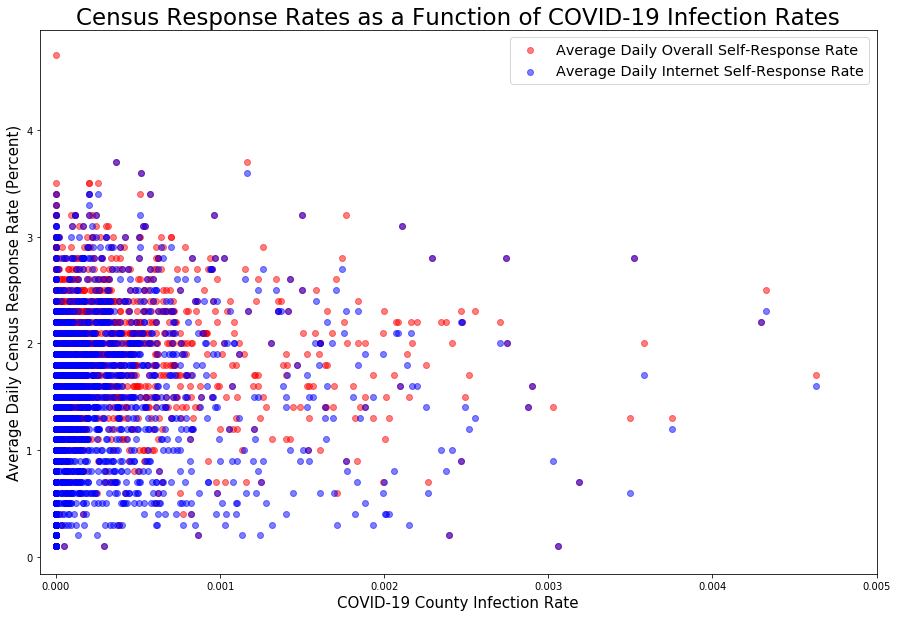

```python
import matplotlib.pyplot as plt

plt.figure(figsize=(15,10))
plt.scatter(full_data['COVID-19 Cases'],\
            full_data['Average Daily Overall Self-Response Rate'],\
           color='r',alpha=0.5)
plt.scatter(full_data['COVID-19 Cases'],\
            full_data['Average Daily Internet Self-Response Rate'],\
            color='b',alpha=0.5)
plt.title('Census Response Rates as a Function of COVID-19 Infection Rates',size=23)
labels=['Average Daily Overall Self-Response Rate','Average Daily Internet Self-Response Rate']
plt.legend(fontsize='x-large')
plt.xlabel('COVID-19 County Infection Rate',size=15)
plt.ylabel('Average Daily Census Response Rate (Percent)',size=15)
plt.xlim(-.0001,.005)
plt.show()
```

## Is This A Real Relationship?

We know that [census response rates tend to vary in areas with different demographics](https://bwliv.github.io/undercount_modeling).

With that in mind, I looked across the counties in our dataset to see if prevalence of COVID-19 still negatively correlated with the "overall" census response rates after conditioning on several demographic factors.

To do that, we will examine *partial correlations* - which are similar to correlations in that they look for a relationship, but instead ask "*controlling for everything else here*, is there a relationship?"

In other words, is there a real relationship between reported COVID-19 cases and census response rates, and not one that's simply a mirage caused by the demographics of counties?

Generally, if the latter was true, then these two variables would have a partial correlation close to zero (as pretty much all the demographic factors do, since they're collectively correlated) - and as you can see below, that wasn't the case, so these demographic factors do not appear to be behind the negative correlation between COVID-19 prevalence and census response rates.

```python
'''
Following script run in R:

library(ppcor)
data = read.csv('full_data.csv',header=T)[-1]
data_overall = 1000* data[c(1,2:5,7:8,10:15,18)]
overall_cors = pcor(data_overall)[['estimate']]
rownames(overall_cors) = colnames(overall_cors) = colnames(data_overall)
write.csv(overall_cors,'overall_rate_partial_cors.csv')
'''

parcors = pd.read_csv('overall_rate_partial_cors.csv')
parcors.index = parcors.iloc[:,0]
parcors = pd.DataFrame(parcors.iloc[0,2:]).astype('float32').round(2).iloc[::-1]
parcors.columns = ['Partial Correlation with COVID-19 infection rates']
parcors
```

|  | Partial Correlation with COVID-19 infection rates |
| --- | --- |
| Average.Daily.Overall.Self.Response.Rate | -0.28 |
| make_over_75k | 0.00 |
| below_poverty_level | -0.05 |
| foreign_born | -0.01 |
| noncitizen | -0.02 |
| under18 | 0.03 |
| hispanic | 0.00 |
| other_race | -0.09 |
| pacific_islander | 0.02 |
| AIAN | 0.02 |
| black | -0.05 |
| white | -0.00 |
| population | -0.07 |

# Conclusion

Overall, we find that counties with higher reported infection rates have generally filled out census forms at a slower rate.

It is very important to note that confounding variables may play a role here, so we can't claim that COVID-19 is slowing census responses. It may be that other demographic characteristics that we did not examine here lead to higher COVID-19 infection rates also lead to lower census response rates.

That being said, we do observe that higher reported COVID-19 infection rates have tended to pair with somewhat lower census response rates, even when factoring out basic socioeconomic characteristics of counties.